# Session 3 · Lab 2: From OLS to Lasso — Bias-Variance and Variable Selection

- Show All Code
- Hide All Code
- View Source

CRISP-DM Phases 4–5 — Modelling and Evaluation under Regularisation

Author

Prof. Dr. Jörg Schoder

Published

today

# 1 Scenario — A Second Memo from Sarah Chen

Lab 1 ended with two memos to Sarah. This morning, a follow-up arrives.

**Note📧 Memo from Sarah Chen, VP Marketing — Dominick’s Finer Foods**

*“Quick follow-up on yesterday’s work. I should have mentioned earlier: we also have census-based demographics for every store catchment area — median income, education levels, age distribution, that kind of thing. Eleven variables per store.*

**Two questions:**

*1. **Would adding those demographics improve the inventory prediction tool you’re building?** Operations is asking how confident we can be in the model. The board likes more variables (‘better information’), but I want a defensible answer, not just more numbers.*

*2. **Does adding demographics tell us anything new about the advertising effect?** I know yesterday you said the historical data alone can’t give us a clean causal estimate. But if we had richer controls — does that change the picture?“*

— Sarah

## 1.1 Lab Objectives

Sarah’s questions align with our two fundamental methodological paths:

- Question 2 is a **Path E1** question — does richer control variation resolve the omitted-variable concern from Lab 1?
- Question 1 is a **Path P** question — does adding 11 demographic variables improve out-of-sample prediction?

This Lab is dedicated to the board’s intuition — *more variables means better model results*. We will scrutinize this intuition using empirical methods.

## 1.2 The Lab in CRISP-DM

The following table situates this lab within the broader Data Science project lifecycle:

| Phase | Name | Content | Status |
| --- | --- | --- | --- |
| 1 | Business Understanding | Marketing decisions: explain and predict | Done (Lab 1) |
| 2 | Data Understanding | OJ panel + store demographics (← here) | Refresh in Step 0 |
| 3 | Data Preparation | Reshape for cross-price modelling (← here) | ← This lab (1, 2) |
| 4 | Modelling | Regularisation: Ridge, Lasso, Elastic Net (← here) | ← This lab (3, 4) |
| 5 | Evaluation | Out-of-sample evaluation via CV (← here) | ← This lab (4, 5) |
| 6 | Deployment | Memo to Sarah: which variables matter for prediction? | ← This lab (6) |

## 1.3 Lab Navigation

| Symbol | Box | Meaning | When to read |
| --- | --- | --- | --- |
| ⚠️ | **Red — Action Required** | Mandatory tasks | During live session |
| 💡 | **Green — Best Practice / Tip** | Coding hints, shortcuts | Skim during lab |
| 📚 | **Blue, collapsed — Background** | Concepts, context, derivations | At home |
| ℹ️ | **Blue, open — Note** | Short clarification | Live |

# 2 Step 0 — Bridge from Lab 1 and What This Lab Adds

**The same DGP, two paths, new challenges.** Lab 1 introduced the **data-generating process (DGP)** as the conceptual scaffold for all of Session 3. We worked with `tbl_s114` (one store) and `tbl_stores` (83 stores × 3 brands) and saw two operations on the *same* DGP: Path E1 asks for the structural parameters, Path P asks for the DGP’s outputs under stable structure.

Lab 2 takes **Path P** seriously. We will see that **OLS itself — the BLUE estimator from Lab 1 — is suboptimal for Path P**. The reason: optimal prediction does not require unbiasedness. By accepting a small bias, we can dramatically reduce variance and produce a more accurate inventory tool for Sarah.

The same DGP, the same data — but a different optimisation target, and therefore a different best estimator.

## 2.1 Bringing additional Store-level data into our Analysis

Today we add a third dataset **`tbl_demo`** with eleven additional predictors for each store.

| Dataset | Source | Rows | Columns | Used for |
| --- | --- | --- | --- | --- |
| tbl_s114 | Lab 1: single-store analysis | 351 | 10 | Step 1 reference |
| tbl_stores | Lab 1: 83 stores × 3 brands | 28947 | 10 | Steps 1–6 |
| tbl_demo | New: census demographics | 83 | 12 | Steps 1, 3–6 |
| tbl_full | Joined: tbl_stores + tbl_demo | 28947 | 21 | Steps 3–6 |

The store-level data provided information about the *catchment area* of each store, such as the age structure and income situation in the neighborhood, or the competitive environment. For brevity we call all additional variables from `tbl_demo` demographics $z_s$. Each store has one row in `tbl_demo`:

tbl_demo — first three rows (11 demographics per store)

| store | age60 | educ | ethnic | income | hhlarge | workwom | hval150 | sstrdist | sstrvol | cpdist5 | cpwvol5 |
| --- | --- | --- | --- | --- | --- | --- | --- | --- | --- | --- | --- |
| 2 | 0.2328647 | 0.24893493 | 0.11427995 | 10.55321 | 0.1039534 | 0.3035853 | 0.46388707 | 2.110122 | 1.1428571 | 1.927280 | 0.3769266 |
| 5 | 0.1173680 | 0.32122573 | 0.05387528 | 10.92237 | 0.1030916 | 0.4105680 | 0.53588336 | 3.801998 | 0.6818182 | 1.600573 | 0.7363068 |
| 8 | 0.2523940 | 0.09517327 | 0.03524333 | 10.59701 | 0.1317497 | 0.2830747 | 0.05422716 | 2.636333 | 1.5000000 | 2.905384 | 0.6410159 |

**Note📚 Background: What each demographic variable measures**

| Variable | Meaning | Unit |
| --- | --- | --- |
| `age60` | Proportion of population aged 60+ | proportion (0–1) |
| `educ` | Proportion with college degree | proportion (0–1) |
| `ethnic` | Proportion non-white | proportion (0–1) |
| `income` | Log of median household income | log USD |
| `hhlarge` | Proportion of households with ≥ 5 persons | proportion (0–1) |
| `workwom` | Proportion of working women | proportion (0–1) |
| `hval150` | Proportion of houses valued > $150 000 | proportion (0–1) |
| `sstrdist` | Distance to nearest warehouse store | miles |
| `sstrvol` | Sales-ratio: nearest warehouse store / this store | ratio |
| `cpdist5` | Average distance to 5 nearest competing supermarkets | miles |
| `cpwvol5` | Sales-ratio: 5 nearest competitors / this store | ratio |

Source: Dominick’s Finer Foods marketing data, originally distributed with bayesm and analysed extensively in the marketing literature (Kilts Center for Marketing at the University of Chicago Booth School of Business 2018).

When we merge `tbl_stores` with `tbl_demo` using the `left_join()`-function, each weekly observation in a store inherits the demographics of its store. The resulting dataset `tbl_full` now has a clear **panel structure** with three dimensions:

- $s$ = store
- $b$ = brand
- $t$ = week/time

```r
# Merge tbl_stores and tbl_demo
tbl_full <- tbl_stores %>%
              left_join(tbl_demo, by = "store")
tbl_full %>%
  head(3) %>%
  gt() %>%
  gt::tab_header(title = "tbl_full — first three rows of merged data") %>%
  gt::tab_options(table.font.size = "13px")
```

tbl_full — first three rows of merged data

| store | brand | week | logmove | sales | price | price_per_oz | feat | deal | profit | age60 | educ | ethnic | income | hhlarge | workwom | hval150 | sstrdist | sstrvol | cpdist5 | cpwvol5 |
| --- | --- | --- | --- | --- | --- | --- | --- | --- | --- | --- | --- | --- | --- | --- | --- | --- | --- | --- | --- | --- |
| 2 | dominicks | 40 | 9.264829 | 10560 | 1.59 | 0.02484375 | 1 | 1 | 1.01 | 0.2328647 | 0.2489349 | 0.1142799 | 10.55321 | 0.1039534 | 0.3035853 | 0.4638871 | 2.110122 | 1.142857 | 1.92728 | 0.3769266 |
| 2 | dominicks | 46 | 8.987197 | 8000 | 2.69 | 0.04203125 | 0 | 0 | 42.12 | 0.2328647 | 0.2489349 | 0.1142799 | 10.55321 | 0.1039534 | 0.3035853 | 0.4638871 | 2.110122 | 1.142857 | 1.92728 | 0.3769266 |
| 2 | dominicks | 47 | 8.831712 | 6848 | 2.09 | 0.03265625 | 1 | 1 | 25.50 | 0.2328647 | 0.2489349 | 0.1142799 | 10.55321 | 0.1039534 | 0.3035853 | 0.4638871 | 2.110122 | 1.142857 | 1.92728 | 0.3769266 |

We denote the time-invariant store demographics from `tbl_demo` as $\mathbf{z}_s$. These variables vary **only across stores** and are constant over brands and weeks within the same store.

To incorporate the store-level information into our regression model, we need to include the vector $\mathbf{z}_s$, which contains the 11 demographic variables (see above) for each store. This step is not straightforward. The key challenge is that $\mathbf{z}_s$ is **constant within each store**: its values do not change over time (weeks) or across brands within the same location.

In panel data analysis, we often want to account for unobserved, time-invariant characteristics of each store (for example: management quality, floor layout, or foot traffic patterns). We do this by including **store fixed effects** ($\alpha_s$). You can think of $\alpha_s$ as a *store-specific intercept* that **absorbs** *all* unobserved factors that are constant over time for that store.

## 2.2 The Core Modeling Dilemma

**The core problem:** Because our observed demographics ($\mathbf{z}_s$) are also constant within each store, they are perfectly collinear with the store fixed effects ($\alpha_s$). The regression model cannot distinguish between the effect of the measured demographics and the unobserved store-specific factors. **In simpler terms:** The model cannot tell whether a store has systematically higher sales because it is located in a high-income neighborhood (measured by $\mathbf{z}_s$) or because it has an excellent (unmeasured) manager captured by $\alpha_s$. Since neither factor changes from week to week, they are mathematically indistinguishable. This tension between observed demographics and unobserved store heterogeneity is a central theme in this lab — and one we will return to in **Lab 3** from a causal inference viewpoint.

This collinearity can be expressed as:
$$\mathbf{z}_s \text{ is a store-specific constant} \quad \implies \quad
\mathbf{z}_s \text{ is perfectly collinear with the store fixed effect } \alpha_s$$

```r
# === WITH Store Fixed Effects ===
model_with_fe <- lm(logmove ~ log(price) + feat + brand + factor(store) +
                     age60 + educ + income + hhlarge + workwom,
                   data = tbl_full)

dropped <- names(coef(model_with_fe))[is.na(coef(model_with_fe))]
cat("Variables dropped due to perfect multicollinearity:\n")
```

```
Variables dropped due to perfect multicollinearity:
```

```r
print(dropped)
```

```
[1] "age60"   "educ"    "income"  "hhlarge" "workwom"
```

```r
cat("\nNumber of coefficients set to NA:", sum(is.na(coef(model_with_fe))), "\n")
```

```
Number of coefficients set to NA: 5
```

As the output confirms, R automatically drops the demographic variables (assigning them `NA` coefficients) because they contain zero within-store variation. Mathematically this happens because the design matrix becomes singular (not invertible).

But what happens if we remove the store fixed effects from the model?

```r
# === WITHOUT Store Fixed Effects (Contrast) ===
model_no_fe <- lm(logmove ~ log(price) + feat + brand +
                   age60 + educ + income + hhlarge + workwom,
                 data = tbl_full)

#cat("=== WITHOUT Store Fixed Effects ===\n")
#cat("All demographic variables remain in the model.\n")
cat("Number of coefficients:", length(coef(model_no_fe)), "\n")
```

```
Number of coefficients: 10
```

The contrast between these two models reveals a fundamental **econometric trade-off**:

- With store fixed effects (Path E1): We cleanly control for unobserved store heterogeneity, but we mathematically lose the ability to estimate the predictive effect of the observed demographics ($\mathbf{z}_s$).
- Without store fixed effects (Path P): We can retain and estimate the demographic effects to build a richer prediction tool, but we risk omitted variable bias (OVB) because unobserved store characteristics are pushed into the error term.

Because Sarah’s immediate request is to improve the inventory prediction tool (Path P), we must drop the store fixed effects and leverage the observable demographic variables. Having made this decision, we are left with three primary ways to specify the relationship between demographics and brand sales.

## 2.3 The Three Primary Approaches

### 2.3.1 Variant A — Additive Demographics (Full Pooling)

Demographic effects are assumed to be identical across all brands. Dominick’s is the baseline brand, captured by the intercept $\beta_0$.

$$y_{sbt} = \beta_0 + \beta_1 \log\text{price}_{sbt} + \beta_2 \text{feat}_{sbt} + \mathbf{z}_s'\gamma + \beta_3 \mathbb{1}_{MM} + \beta_4 \mathbb{1}_{Trop} + \varepsilon_{sbt}$$
This additive approach is exactly what we just estimated in the `model_no_fe code` block above. It relies on the strong assumption that neighborhood income, for instance, shifts the demand for premium Tropicana and the budget Dominick’s brand by the exact same amount. In reality, this is implausible: premium brands typically have steeper income gradients.

### 2.3.2 Variant B — Separate Models per Brand

To allow for fully brand-specific coefficients, we could split the dataset and run three completely separate regressions (no pooling across brands). Every parameter receives a brand-specific superscript $(b)$.

$$y_{sbt} = \beta_0^{(b)} + \beta_1^{(b)} \log\text{price}_{sbt} + \beta_2^{(b)} \text{feat}_{sbt} + \mathbf{z}_s'\gamma^{(b)} + \varepsilon_{sbt} \qquad \text{(for each brand } b\text{)}$$
Methodological Trade-off: While highly flexible, splitting the dataset severely reduces the sample size for each estimation, leading to a loss of statistical power.

### 2.3.3 Variant C — Full Interaction Model (Main Specification)

This is our central approach for this lab. It keeps all data in a single pooled model but interacts every predictor (price, marketing, and demographics) with the brand indicators. The $\delta$-parameters measure the deviation from the baseline brand (Dominick’s).

$$\begin{align*}
y_{sbt} =& \beta_0 + \beta_1 \log\text{price}_{sbt} + \beta_2 \text{feat}_{sbt} + \mathbf{z}_s'\gamma + \beta_3 \mathbb{1}_{MM} + \beta_4 \mathbb{1}_{Trop} \\
&+ \delta_{1,MM} (\log\text{price}_{sbt} \cdot \mathbb{1}_{MM}) + \delta_{2,MM} (\text{feat}_{sbt} \cdot \mathbb{1}_{MM}) + \mathbf{z}_s' \boldsymbol{\delta}_{MM} \mathbb{1}_{MM} \\
&+ \delta_{1,Trop} (\log\text{price}_{sbt} \cdot \mathbb{1}_{Trop}) + \delta_{2,Trop} (\text{feat}_{sbt} \cdot \mathbb{1}_{Trop}) + \mathbf{z}_s' \boldsymbol{\delta}_{Trop} \mathbb{1}_{Trop} + \varepsilon_{sbt}
\end{align*}$$

Methodological Note: In this specification, the total price effect for *Minute Maid* is exactly $(\beta_1 + \delta_{1,MM})$, which is mathematically equivalent to the isolated $\beta_1^{(MM)}$ parameter from Variant B.

**Warning⚠️ A Note on Modeling Philosophy: Econometrics vs. Machine Learning**

However, our goal here is Path P (Prediction). In modern predictive modeling (Machine Learning), we often prefer to give the algorithm maximum flexibility (a “kitchen sink” approach) and rely on computational methods to prevent overfitting. Variant C will deliberately push OLS to its breaking point, showing exactly why we need regularization techniques like Lasso to do the sorting for us

# 3 Step 1 — Demographics as Path E1 Controls

We start by closing the loop on **Sarah’s Question 2**: does richer control variation resolve the omitted-variable concern from Lab 1?

Recall the baseline result on the full panel from Lab 1:

```r
# baseline model from Lab 1 — no demographics, no deal
mod_baseline_full <- lm(logmove ~ feat + log(price) + brand, data = tbl_stores)

# full model with deal (Lab 1 Step 1b)
mod_with_deal     <- lm(logmove ~ feat + deal + log(price) + brand, data = tbl_stores)

bind_rows(
  tidy(mod_baseline_full) %>% mutate(model = "Baseline (Lab 1)"),
  tidy(mod_with_deal)     %>% mutate(model = "With deal (Lab 1)")
) %>%
  filter(term == "feat") %>%
  select(model, estimate) %>%
  mutate(estimate = round(estimate, 3)) %>%
  gt() %>%
  gt::tab_options(table.font.size = "13px")
```

| model | estimate |
| --- | --- |
| Baseline (Lab 1) | 0.879 |
| With deal (Lab 1) | 0.841 |

The Lab 1 finding: adding `deal` reduces $\hat\beta_{\text{feat}}$ by about **0.038** log units — this is the omitted-variable bias from the structural feat × deal bundling.

Now we test whether **demographic controls** make a similar difference:

```r
# Expanded model with 11 demographics
mod_with_demos <- lm(
  logmove ~ feat + deal + log(price) + brand +
    age60 + educ + ethnic + income + hhlarge + workwom +
    hval150 + sstrdist + sstrvol + cpdist5 + cpwvol5,
  data = tbl_full
)

bind_rows(
  tidy(mod_baseline_full)  %>% mutate(model = "Baseline (Lab 1)"),
  tidy(mod_with_deal)      %>% mutate(model = "With deal (Lab 1)"),
  tidy(mod_with_demos)     %>% mutate(model = "With deal + demographics")
) %>%
  filter(term == "feat") %>%
  select(model, estimate) %>%
  mutate(estimate = round(estimate, 3)) %>%
  gt() %>%
  gt::tab_options(table.font.size = "13px")
```

| model | estimate |
| --- | --- |
| Baseline (Lab 1) | 0.879 |
| With deal (Lab 1) | 0.841 |
| With deal + demographics | 0.838 |

**Important⚠️ T1: What do you see?**

1. By how much does $\hat\beta_{\text{feat}}$ change when demographics are added to the with-deal model?
2. Compare this to the OVB shift from Lab 1 (baseline → with-deal). Which control variable changed the estimate more?
3. What does this tell you about Sarah’s Question 2 — does richer demographic control resolve the advertising-effect question?

Note your answers before opening the solution box.

**Note🟢 Interpretation (Click to unfold)**

Adding the 11 demographics changes $\hat\beta_{\text{feat}}$ by only a fraction of a log unit — far less than the shift caused by adding deal. The structural feat × deal bundling remains the dominant source of OVB; demographic variation in store catchment areas does not substantially confound the advertising effect.

This is a defensible finding for Sarah’s Question 2. Demographics do not resolve the causal interpretation. The advertising effect remains identified only up to its bundling with deal. That identification problem requires a dedicated study design (Lab 3), not merely additional control variables.

**Tip💡 Could demographics still matter causally?**

Demographics could plausibly cause `logmove` through several channels:

- **Income**: higher-income areas may have different brand-loyalty patterns
- **Age**: older shoppers may prefer established brands like Tropicana
- **Household size**: large households may buy more juice per shopping trip

These mechanisms make the demographics legitimate causal predictors in their own right. The empirical finding here is more subtle: while demographics *do* explain variation in `logmove` (some of their coefficients are highly significant), they do not change the estimated advertising effect. Causal interpretation of $\hat\beta_{\text{feat}}$ is therefore not blocked by demographic confounding.

The Path E1 question is answered. From Step 2 onwards we are firmly on Path P — out-of-sample prediction.

# 4 Step 2 — Cross-Price Elasticities

In Lab 1 we modelled `log(price)` as the *own* brand’s price. But shoppers don’t see brands in isolation: on the supermarket shelf, Tropicana, Minute Maid and Dominick’s compete for the same customer base. If Tropicana is discounted, economists would expect a fraction of Dominick’s customers to switch brands.

Capturing this **substitution effect** requires the inclusion of competing brands’ prices in the same regression equation.

## 4.1 Reshaping the Panel: From Long to Semi-Wide

Our integrated dataset `tbl_full` currently contains one row per `(store, brand, week)`. For cross-price modelling, we require one row per `(store, week)`, with the prices, sales, and marketing levers of all three brands represented as separate columns.

We can achieve this using the `pivot_wider()` function:

**Note📚 Background: Reshaping with time-invariant demographics**

By reshaping the integrated `tbl_full` dataset directly, we gain a major structural advantage. Because the 11 demographic variables are constant across brands and weeks within a given store, `pivot_wider()` automatically treats them as identifier columns (just like `store` and `week`).

They remain neatly intact as single columns, while only the brand-varying features (like `price` and `logmove`) are expanded and receive brand-specific suffixes. This elegant behavior saves us from having to merge the demographics back into the dataset later.

```r
tbl_cross <- tbl_full %>%
  select(store, week, brand, logmove, price, feat, deal,
         age60, educ, ethnic, income, hhlarge, workwom,
         hval150, sstrdist, sstrvol, cpdist5, cpwvol5) %>%
  pivot_wider(
    names_from  = brand,
    values_from = c(logmove, price, feat, deal),
    names_glue  = "{.value}_{brand}"
  )

# Inspect the new structure
tbl_cross %>%
  head(3) %>%
  select(store, week, income, educ, # Demographics remain seamlessly integrated
         logmove_dominicks, price_dominicks,
         price_minute.maid, price_tropicana) %>%
  gt() %>%
  gt::tab_options(table.font.size = "11px")
```

| store | week | income | educ | logmove_dominicks | price_dominicks | price_minute.maid | price_tropicana |
| --- | --- | --- | --- | --- | --- | --- | --- |
| 2 | 40 | 10.55321 | 0.2489349 | 9.264829 | 1.59 | 3.17 | 3.87 |
| 2 | 46 | 10.55321 | 0.2489349 | 8.987197 | 2.69 | 3.17 | 3.87 |
| 2 | 47 | 10.55321 | 0.2489349 | 8.831712 | 2.09 | 2.39 | 3.87 |

The transformed dataset `tbl_cross` now has one row per store-week combination.

## 4.2 Estimating Competitor Elasticities

We can now specify a demand model for one specific brand (e.g., Dominick’s) that includes the marketing mix of its competitors.

```r
mod_cross_dom <- lm(
  logmove_dominicks ~
    log(price_dominicks) + log(price_minute.maid) + log(price_tropicana) +
    feat_dominicks   + deal_dominicks +
    feat_minute.maid + deal_minute.maid +
    feat_tropicana   + deal_tropicana,
  data = tbl_cross
)

mod_cross_dom %>%
  tidy() %>%
  filter(stringr::str_detect(term, "price")) %>%
  select(term, estimate, std.error, p.value) %>%
  mutate(across(where(is.numeric), \(x) round(x, 4))) %>%
  gt() %>%
  gt::tab_options(table.font.size = "13px")
```

| term | estimate | std.error | p.value |
| --- | --- | --- | --- |
| log(price_dominicks) | -2.9360 | 0.0438 | 0 |
| log(price_minute.maid) | 0.8806 | 0.0592 | 0 |
| log(price_tropicana) | -0.3208 | 0.0532 | 0 |

The three price coefficients represent the price elasticities: the expected percentage change in `logmove_dominicks` for a 1% change in each respective brand’s price.

**Important⚠️ T2: Read the elasticity table**

1. What sign does the own-price elasticity have for Dominick’s? Is the magnitude larger or smaller than the value from Lab 1 (≈ -2.47)?
2. What sign do the *cross*-price elasticities (Minute Maid, Tropicana) have? What does the sign say about substitution?
3. Compare the magnitude of the cross-price elasticities to the own-price elasticity. Which competitor moves Dominick’s sales more?

**Note🟢 Interpretation (Click to unfold)**

**Tip💡 Methodological observation**

This is a Path-E1 improvement — including a confounder (competitor price) made the own-price estimate more credible. But it is also a Path-P improvement — the model now captures variation that the Lab-1 baseline missed.

**Warning⚠️ Data gap reminder**

The `orangeJuice` dataset originally contains 11 brand prices per observation. In our reduction to the top three brands, we kept only their own prices. **Cross-price effects from the 8 omitted brands (Florida Natural, Citrus Hill, etc.) are lost.**

For Dominick’s, Minute Maid and Tropicana — the three best-selling brands — the competitive pressure is reasonably captured by our three included brands. For a complete competitive analysis, the full 11-brand price matrix would be needed.

This is a typical data-gap situation: we work with what we have, and honestly report what we cannot say.

This cross-price setup is still well within the comfort zone of classical OLS. But what happens when we combine these competitor dynamics with the demographic heterogeneities from Step 1? In the next step, the model dimension will grow to a point where classical OLS begins to fail.

# 5 Step 3 — High-Dimensional OLS and the Overfitting Trap

To construct Variant C (the full interaction model), we return to the long-format `tbl_full`. Including cross-prices and demographic interactions simultaneously would expand the parameter space beyond what is computationally practical for a standard exercise.

Instead, we focus on capturing the brand-specific effects of demographics and marketing levers by interacting every variable with `brand`.

## 5.1 Building the Full Interaction Specification

```r
mod_full_spec <- lm(
  logmove ~ feat * brand + deal * brand + log(price) * brand +
    age60 * brand + educ * brand + ethnic * brand + income * brand +
    hhlarge * brand + workwom * brand + hval150 * brand +
    sstrdist * brand + sstrvol * brand + cpdist5 * brand + cpwvol5 * brand,
  data = tbl_full
)

# Parameter count
n_params <- length(coef(mod_full_spec))
cat("Number of parameters in full specification: ", n_params, "\n")
```

```
Number of parameters in full specification:  45
```

**Note📚 Background: Four problems of big-data regression (Fan, Han, Liu 2014)**

Even when $n$ is comfortably large relative to $p$, four issues from the big-data literature (Fan, Han, and Liu 2014) become operative as we add parameters:

1. **Noise accumulation.** With more parameters, the variance of the estimator grows. Even if each additional variable has a small true effect, its sample estimate contributes noise that compounds.
2. **Spurious correlation.** In high dimensions, the probability of finding apparently strong correlations *by chance* increases rapidly. Lasso (Step 5) will retain some of these spurious selections.
3. **Incidental endogeneity.** Some predictors may be correlated with omitted causes — even when they have no causal effect on $y$, they pick up the omitted signal. The regression’s causal interpretation breaks silently.
4. **Measurement errors.** Census-based demographic variables measure what they measure imperfectly. With more such variables, compound measurement noise grows.

These four problems frame why **regularisation is not enough**. Lasso handles (1) and partially (2); it does not solve (3) and (4). Reading Lasso-selected variables as “important predictors” must always be qualified by these limitations.

## 5.2 Evaluating In-Sample Performance

We first examine the specification’s in-sample fit:

```r
broom::glance(mod_full_spec) %>%
  select(r.squared, adj.r.squared, sigma, AIC, BIC, nobs) %>%
  mutate(across(where(is.numeric), \(x) round(x, 3))) %>%
  gt() %>%
  gt::tab_options(table.font.size = "12px")
```

| r.squared | adj.r.squared | sigma | AIC | BIC | nobs |
| --- | --- | --- | --- | --- | --- |
| 0.608 | 0.608 | 0.639 | 56232.61 | 56613.18 | 28947 |

The in-sample R² is **0.608**. The in-sample RMSE is **0.638**. Compared to the Lab 1 baseline **RMSE** on the full panel (0.714), the full specification fits the training data much better.

**Note📚 Background: OLS, Overfitting, and the Bias-Variance Decomposition**

To evaluate out-of-sample performance, we must understand why even an “unbiased” model like OLS fails in high dimensions.

**1. The Classical Benchmark: OLS Unbiasedness** Under classical assumptions, OLS is the Best Linear Unbiased Estimator (BLUE). It is unbiased by design ($\text{Bias} = 0$). In the simple models of Lab 1, this property is our gold standard: on average, our estimates hit the true parameter value.

**2. The Bias-Variance Decomposition** For a fixed query point and an estimator trained on a random sample, the expected squared prediction error decomposes as:

$$\mathbb{E}\left[(y_0 - \hat f(x_0))^2\right] = \underbrace{\left(\mathbb{E}[\hat f(x_0)] - f(x_0)\right)^2}_{\text{Bias}^2} + \underbrace{\mathrm{Var}(\hat f(x_0))}_{\text{Variance}} + \underbrace{\sigma^2}_{\text{Irreducible error}}$$

- **Bias²:** measures the systematic error (due to model simplification): on average, how far off is the estimator?
- **Variance:** measures the sensitivity to the training sample: if we resampled the data, how much would $\hat f(x_0)$ change?
- **$\sigma^2$:** is the noise in the DGP itself — no estimator can eliminate it.

**3. The Overfitting Dilemma** As we increase the number of parameters ($p$), the model gains flexibility to fit idiosyncratic noise in the training sample. While OLS remains unbiased (Bias² stays near zero), the model’s **Variance** component explodes.

- **In-sample:** The model perfectly follows the noise, and the MSE (and RMSE) drops.
- **Out-of-sample:** The model attempts to apply these noise-patterns to new data where they do not exist. The error skyrockets. This is the **Overfitting Dilemma**: by demanding zero bias, we pay the price in variance.

**4. Operationalizing the Error** To measure this trade-off, we use:

- **MSE (Mean Squared Error):** The mathematical objective function to be minimized.
  $$\text{MSE} = \frac{1}{n} \sum_{i=1}^{n} (y_i - \hat{y}_i)^2$$
- **RMSE (Root Mean Squared Error):** Defined as $\sqrt{\text{MSE}}$. We primarily report the RMSE because taking the square root translates the error metric back into the original units of the dependent variable (in our case, log units of sales), making it directly interpretable.

**Conclusion:** By accepting a small amount of **Bias** (through shrinkage/regularization), we can drastically reduce **Variance**, leading to a lower total out-of-sample MSE than the “unbiased” OLS model.

**Important⚠️ T3: In-sample vs. out-of-sample expectations**

1. The in-sample R² has improved substantially from Lab 1. Should we conclude that the new model is a better prediction tool for Sarah’s inventory planning?
2. What is the difference between *in-sample* performance and *out-of-sample* performance? Why does the distinction matter for Sarah’s question?
3. Predict (before computing) what will happen if we evaluate `mod_full_spec` via 5-fold cross-validation across stores.

**Note🟢 The trap of in-sample R² (Click to unfold)**

A higher in-sample R² tells us only that the model fits the data we *already have*. The relevant question for Sarah’s inventory tool is how well the model will predict in stores or weeks the model has *not seen*. These two quantities can diverge sharply when:

- The number of parameters is large relative to the effective sample size (clustering reduces effective n)
- Predictors are highly correlated (the educ / income / hval150 cluster from the demographics)
- The model captures sample-specific noise that does not generalise

This is **overfitting**. The next step measures it directly.

## 5.3 The Overfitting Trap

To build an intuition for why adding parameters eventually degrades predictive performance, consider a polynomial regression attempting to capture a noisy, non-linear signal.

**Show code: Visualizing the Overfitting Concept**

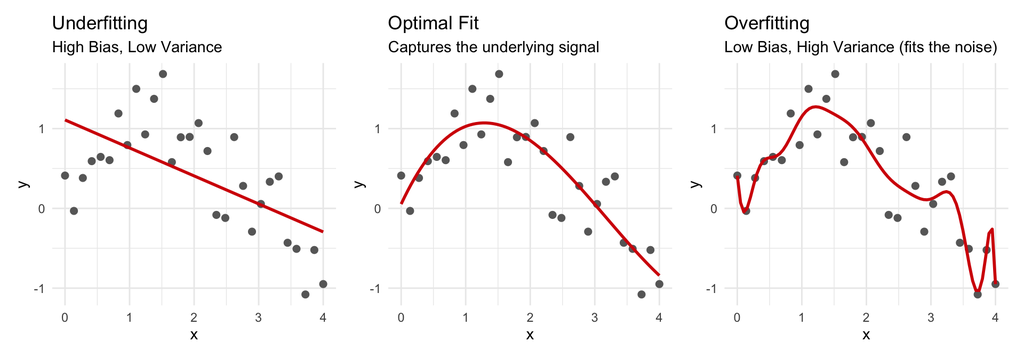

```r
library(ggplot2)
library(patchwork)

# Set the corporate/academic color palette
col_primary   <- "#D50006"   # main highlight (used for models)
col_secondary <- "#502479"   # contrast
col_neutral   <- "#686868"   # grey reference (used for data points)

# Simulate a simple non-linear relationship with noise
set.seed(42)
x_demo <- seq(0, 4, length.out = 30)
y_demo <- sin(x_demo) + rnorm(30, sd = 0.3)
df_demo <- data.frame(x = x_demo, y = y_demo)

p1 <- ggplot(df_demo, aes(x, y)) +
  geom_point(color = col_neutral, size = 2) +
  geom_smooth(method = "lm", formula = y ~ x, se = FALSE, color = col_primary) +
  labs(title = "Underfitting", subtitle = "High Bias, Low Variance") +
  theme_minimal()

p2 <- ggplot(df_demo, aes(x, y)) +
  geom_point(color = col_neutral, size = 2) +
  geom_smooth(method = "lm", formula = y ~ poly(x, 3), se = FALSE, color = col_primary) +
  labs(title = "Optimal Fit", subtitle = "Captures the underlying signal") +
  theme_minimal()

p3 <- ggplot(df_demo, aes(x, y)) +
  geom_point(color = col_neutral, size = 2) +
  geom_smooth(method = "lm", formula = y ~ poly(x, 15), se = FALSE, color = col_primary) +
  labs(title = "Overfitting", subtitle = "Low Bias, High Variance (fits the noise)") +
  theme_minimal()

# Display side-by-side using patchwork
p1 | p2 | p3
```

To determine if our full specification is overfitting the dataset—similar to the high-variance polynomial in the third panel—it must be evaluated on unseen data.

## 5.4 Evaluating Out-of-Sample Performance via Cross-Validation

We apply the 5-fold cluster-robust cross-validation protocol established in Lab 1 to both the baseline model and the full interaction specification. By splitting the data at the `store` level (whole-store assignment to folds, as detailed in Lab 1’s `#cluster-cv` background box), we ensure that entire locations serve as isolated test sets.

This strategy protects against the data leakage that would inevitably arise from random, observation-level splitting in highly autocorrelated panel data, providing a fair and rigorous comparison of generalization performance.

```r
set.seed(42)
K <- 5
stores_shuffled <- sample(unique(tbl_full$store))
folds <- cut(seq_along(stores_shuffled), breaks = K, labels = FALSE)

cv_rmse <- function(formula_str, label) {
  rmses <- map_dbl(1:K, \(k) {
    test_st  <- stores_shuffled[folds == k]
    train_st <- stores_shuffled[folds != k]
    mod_k    <- lm(as.formula(formula_str),
                   data = tbl_full %>% filter(store %in% train_st))
    pred_k   <- predict(mod_k,
                        newdata = tbl_full %>% filter(store %in% test_st))
    actual_k <- tbl_full %>% filter(store %in% test_st) %>% pull(logmove)
    sqrt(mean((pred_k - actual_k)^2))
  })
  tibble(model = label, mean_rmse = mean(rmses), sd_rmse = sd(rmses))
}

formula_baseline <- "logmove ~ feat + log(price) + brand"
formula_full     <- "logmove ~ feat * brand + deal * brand + log(price) * brand +
                       age60 * brand + educ * brand + ethnic * brand + income * brand +
                       hhlarge * brand + workwom * brand + hval150 * brand +
                       sstrdist * brand + sstrvol * brand + cpdist5 * brand + cpwvol5 * brand"

cv_results <- bind_rows(
  cv_rmse(formula_baseline, "OLS — baseline (Lab 1)"),
  cv_rmse(formula_full,     "OLS — full specification")
) %>%
  mutate(across(where(is.numeric), \(x) round(x, 3)))

cv_results %>%
  gt() %>%
  gt::tab_options(table.font.size = "12px")
```

| model | mean_rmse | sd_rmse |
| --- | --- | --- |
| OLS — baseline (Lab 1) | 0.716 | 0.019 |
| OLS — full specification | 0.652 | 0.009 |

**Important⚠️ T4: Evaluate the Cross-Validation Results**

1. The full interaction specification exhibited a higher in-sample $R^2$ than the baseline model. How do their cross-validated RMSEs compare?
2. Did the addition of the demographic parameters improve or deteriorate the out-of-sample prediction?
3. What does this indicate regarding the assumption that “more variables equate to better information”?

**Note🟢 Interpretation (Click to unfold)**

The full interaction specification yields a **lower** out-of-sample RMSE (approx. 0.652) than the baseline model (0.716).

Contrary to the theoretical fear of overfitting, the expanded model generalized successfully to unseen locations. The out-of-sample performance improved because the demographic interactions capture genuine, stable market heterogeneities rather than idiosyncratic noise. In this specific setting, **45 parameters are not yet sufficient to exhaust the effective degrees of freedom** provided by 83 distinct store clusters.

This empirical result partially vindicates the board’s assumption: in this large-sample regime, adding structural variables did indeed provide “better information” and improved the predictive tool.

However, this raises a new **methodological question:** Are all 45 parameters strictly necessary to achieve this improved accuracy?

# 6 Step 4 — The Classical Selection Problem and Its Critiques

While the 45-parameter specification (`mod_full_spec`) demonstrated robust out-of-sample performance without overfitting, predictive models deployed in production prioritize **sparsity**. A sparse model achieves high predictive accuracy using the minimum necessary number of features. Sparsity reduces deployment complexity, mitigates the risk of structural breaks in future data, and enhances interpretability.

The analytical objective therefore shifts from merely maximizing predictive accuracy to identifying a parsimonious model.

## 6.1 Old-School Algorithms: Backward Elimination

Historically, a standard algorithmic procedure for dimensionality reduction was **stepwise selection** (specifically, backward elimination). The algorithm follows a sequential heuristic, typically minimizing the Akaike Information Criterion (AIC):

1. Estimate the full model with all $p$ variables.
2. Evaluate the removal of each variable sequentially to see which deletion yields the lowest AIC.
3. Remove the variable that improves (lowers) the AIC the most.
4. Re-estimate the model with $p-1$ variables.
5. Repeat the iterative process until removing any further variable increases the AIC.

**Note📚 Background: Information Criteria (AIC and BIC)**

In model selection, evaluating performance exclusively via in-sample metrics (like $R^2$ or RMSE) inevitably leads to overfitting. Information criteria provide a theoretical alternative: they approximate out-of-sample prediction error by mathematically penalizing the model for adding parameters.

Both criteria aim to minimize their respective scores, balancing goodness-of-fit against model complexity.

**1. Akaike Information Criterion (AIC)** Derived from information theory, the AIC estimates the relative amount of information lost by a given model.
$$\text{AIC} = 2p - 2\ln(\hat{L})$$
* $p$: The number of estimated parameters. * $\hat{L}$: The maximum value of the likelihood function for the model (a measure of fit). The penalty term ($2p$) increases linearly with the number of predictors, penalizing complexity.

**2. Bayesian Information Criterion (BIC)** Also known as the Schwarz criterion, the BIC is grounded in Bayesian probability.
$$\text{BIC} = p\ln(n) - 2\ln(\hat{L})$$
* $n$: The number of observations in the sample. Because the penalty multiplier is $\ln(n)$ rather than a constant $2$, the BIC imposes a much stricter penalty on complexity for any dataset where $n \ge 8$.

**Methodological Implication for our Dataset:** With $n \approx 28,000$, the BIC penalty per parameter is $\ln(28000) \approx 10.2$, which is five times harsher than the AIC penalty of $2$. Consequently, an algorithm minimizing the BIC will generally select a much sparser (simpler) model than one minimizing the AIC. The base R `step()` function defaults to AIC ($k=2$).

We can apply this classical algorithm using the base R `step()` function.

```r
# Perform backward stepwise selection (trace = 0 suppresses the voluminous output)
mod_backward <- step(mod_full_spec, direction = "backward", trace = 0)

# Compare parameter counts
cat("Parameters in full model:     ", length(coef(mod_full_spec)), "\n")
```

```
Parameters in full model:      45
```

```r
cat("Parameters in backward model: ", length(coef(mod_backward)), "\n")
```

```
Parameters in backward model:  41
```

The algorithm reduces the parameter count from 45 to 41. While the model remains computationally stable, the selection process reveals a significant underlying issue: in high-dimensional settings containing highly correlated predictors (such as the demographic clusters), the stepwise selection path becomes volatile. Small variations in the training data can cause the algorithm to include or exclude variables arbitrarily, undermining the reliability of the final model.

To visualize this instability, we can bootstrap the selection process:

```r
set.seed(42)
n_boot <- 5

boot_results <- replicate(n_boot, {
  # Reduce sample size to visualize volatility
  d_boot <- tbl_full[sample(nrow(tbl_full), size = 150, replace = TRUE), ]

  # Stepwise Regression
  m_boot <- MASS::stepAIC(lm(logmove ~ ., data = d_boot), direction = "backward", trace = 0)
  names(coef(m_boot))[-1]
}, simplify = FALSE)

# Show findings
cat("Number of variables selected per run: ", sapply(boot_results, length), "\n")
```

```
Number of variables selected per run:  9 12 10 10 12
```

```r
stable_vars <- Reduce(intersect, boot_results)
cat("Stable variables (in all runs): ", length(stable_vars), "\n")
```

```
Stable variables (in all runs):  5
```

The results are sobering: The algorithm produces a different model for every bootstrap sample, and only a handful of variables remain stable. This confirms the classic critique by Frank Harrell: stepwise selection is not a robust statistical method; it is a search for noise that happens to align with the current sample. Beyond these stability concerns, modern statistical literature strongly discourages this approach for both inferential and predictive tasks.

## 6.2 Why Stepwise Selection Fails: The Harrell Critique

The mechanical reduction of variables via `step()` may seem computationally convenient, yet we must critically evaluate the statistical validity of the resulting model. Frank Harrell (Harrell 2015) provides a seminal critique of these automated procedures, highlighting why they undermine the integrity of our inferences:

**Warning**

⚠️ Methodological Critique: The Instability of Stepwise Methods

Frank Harrell (Harrell 2015) systematically outlines the methodological flaws of stepwise selection algorithms. When the dataset is used iteratively to dictate the model structure, the classical assumptions of OLS inference are fundamentally violated:

1. **Multiple Testing & $p$-Hacking**: Stepwise selection is a form of automated p-hacking. By searching through thousands of possible combinations to find the “best” fit, the probability of selecting predictors that have no true effect but appear significant by chance is nearly 100%.
2. **Downward Biased Standard Errors:** The final model (mod_backward) reports standard errors as if the selected variables were known a priori. By ignoring the severe uncertainty of the selection path, these standard errors are artificially small, rendering confidence intervals invalid.
3. **Biased Coefficients:** Variables that survive the selection process systematically overestimate the true effect size (a phenomenon related to the “winner’s curse”).
4. **Path Dependence:** The algorithm evaluates local optima. Removing one variable fundamentally alters the partial correlations of all remaining variables, meaning stepwise selection is not mathematically guaranteed to identify the globally optimal predictive model.

To avoid automated multiple-testing issues, computational singularities, and invalid inference, a methodology is required that performs variable selection simultaneously with parameter estimation, rather than sequentially.

In high-dimensional settings containing highly correlated predictors, we must transition from discrete selection algorithms to continuous penalty functions. This leads us to **regularization**.

# 7 Step 5 — LASSO: Bias Accepted for Lower MSE

To address the limitations of stepwise selection without sacrificing predictive accuracy, we apply regularization. Specifically, we utilize the Least Absolute Shrinkage and Selection Operator (LASSO) introduced by Tibshirani (1996).

## 7.1 The L1 Penalty and Algorithmic Variable Selection

Regularization techniques deliberately introduce a degree of bias into the parameter estimates to achieve a substantial reduction in out-of-sample variance. The Lasso estimator modifies the OLS objective function by appending an $L_1$ penalty term based on the absolute magnitude of the coefficients:

$$\hat{\beta}_{\text{Lasso}} = \arg\min_\beta \left\{ \sum_{i=1}^n (y_i - x_i^\top \beta)^2 + \lambda \sum_{j=1}^p |\beta_j| \right\}$$

The hyperparameter $\lambda$ dictates the severity of the penalty:

- For $\lambda = 0$, Lasso simplifies to the standard OLS estimator.
- As $\lambda \to \infty$, the penalty dominates, forcing all coefficients to zero.

To determine the optimal balance, we select the $\lambda$ that minimizes out-of-sample MSE through cross-validation. This empirical optimization process represents a deliberate statistical trade-off: by accepting a small amount of bias in our coefficient estimates, we achieve a significant reduction in model variance.

**Note📚 Background: Lasso vs. Ridge — and why Lasso selects variables**

Ridge regression uses an $L_2$ penalty ($\sum \beta_j^2$); Lasso uses $L_1$. The geometric consequence is that Lasso’s penalty corners on the coordinate axes push small coefficients exactly to zero, while Ridge shrinks them smoothly toward zero without setting them to zero.

| Method | Penalty | Shrinks toward 0 | Sets to 0 | Use case |
| --- | --- | --- | --- | --- |
| OLS | none | no | no | Low-dim, BLUE conditions |
| Ridge | $L_2$ | yes | no | High correlation, all variables matter |
| Lasso | $L_1$ | yes | **yes** | Variable selection — sparse signal |
| Elastic Net | $L_1 + L_2$ | yes | yes | Mixture: groups + selection |

For our setting — many highly correlated demographics, plus the suspicion that only a few matter for prediction — Lasso is the natural choice: it automatically filters redundant demographic variables.

**Note📚 Background: The Bias-Variance Tradeoff — A Strategic Perspective**

In Step 3, we mathematically diagnosed overfitting via the bias-variance decomposition. Now, we use this framework to motivate regularization (Lasso and Ridge).

**The Econometric Reading: Accepting Bias for Efficiency** As established, OLS minimizes variance *among linear unbiased estimators* (the BLUE condition). It does not minimize variance *overall*. By accepting a small, controlled bias (through shrinkage), we move outside the BLUE restriction and can find estimators with significantly lower total MSE.

**The Strategic Reading (Spiess 2025):** A researcher with private preferences (publication pressure, client expectations, ideological priors) could exploit the bias-variance trade-off by tuning regularization parameters until a “favoured” estimate emerges.

This provides a modern justification for the classical econometric insistence on *unbiasedness*: it functions as an institutional restriction against specification-hacking.

- When using Lasso for **prediction** (Path P), the bias is a deliberate efficiency choice.
- When we use it for **causal claims** (Path E), the bias becomes a credibility liability — unless we fix the bias *ex ante* via sample-splitting (Lab 3, Double Machine Learning (Chernozhukov et al. 2018)).

## 7.2 Implementation with **glmnet**

The implementation requires the separation of the data into a design matrix ($X$) and a response vector ($y$).

```r
# build the design matrix for the full specification
X_full <- model.matrix(as.formula(formula_full), data = tbl_full)[, -1]
y_full <- tbl_full$logmove

cat("Design matrix dimensions: ", dim(X_full), "\n")
```

```
Design matrix dimensions:  28947 44
```

We determine the optimal penalty parameter $\lambda$ through 5-fold cross-validation.

```r
set.seed(42)
# alpha = 1 specifies the Lasso penalty (alpha = 0 implements Ridge)
cv_lasso <- cv.glmnet(X_full, y_full, alpha = 1, nfolds = 5)

# Saving lambda.min and lambda.1se for inline referencing
lambda_min <- cv_lasso$lambda.min
lambda_1se <- cv_lasso$lambda.1se

# Extract optimized lambda values
cat("lambda.min (minimizes CV-MSE): ", round(cv_lasso$lambda.min, 5), "\n")
```

```
lambda.min (minimizes CV-MSE):  0.00055
```

```r
cat("lambda.1se (parsimonious model): ", round(cv_lasso$lambda.1se, 5), "\n")
```

```
lambda.1se (parsimonious model):  0.00824
```

## 7.3 The cross-validation curve

**Show code: Clean Lasso CV plot with thinned labels**

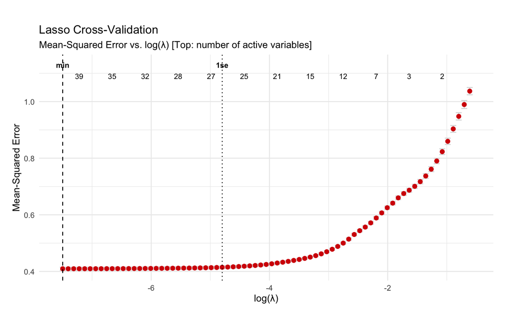

```r
# 1. Extract data
lasso_df <- data.frame(
  lambda = cv_lasso$lambda,
  cvm    = cv_lasso$cvm,
  cvup   = cv_lasso$cvup,
  cvlo   = cv_lasso$cvlo,
  nzero  = cv_lasso$nzero
)

# 2. Labels
top_labels <- lasso_df %>%
  mutate(idx = row_number()) %>%
  filter(idx %% 6 == 0)

# 3. Plot
ggplot(lasso_df, aes(x = log(lambda), y = cvm)) +
  geom_errorbar(aes(ymin = cvlo, ymax = cvup), color = "grey85", width = 0.1) +
  geom_point(color = "#D50006", size = 2) +
  # Hier die reduzierten Labels
  geom_text(data = top_labels, aes(x = log(lambda), y = max(lasso_df$cvup) + 0.04, label = nzero), size = 3) +
  # Linien
  geom_vline(xintercept = log(cv_lasso$lambda.min), linetype = "dashed") +
  geom_vline(xintercept = log(cv_lasso$lambda.1se), linetype = "dotted") +
  # Annotationen
  annotate("text", x = log(cv_lasso$lambda.min), y = max(lasso_df$cvup) + 0.08,
           label = "min", size = 3, fontface = "bold") +
  annotate("text", x = log(cv_lasso$lambda.1se), y = max(lasso_df$cvup) + 0.08,
           label = "1se", size = 3, fontface = "bold") +
  # Layout
  theme_minimal() +
  labs(
    title = "Lasso Cross-Validation",
    subtitle = "Mean-Squared Error vs. log(λ) [Top: number of active variables]",
    x = "log(λ)",
    y = "Mean-Squared Error"
  ) +
  coord_cartesian(clip = "off") +
  theme(plot.margin = unit(c(2, 1, 1, 1), "lines"))
```

- **Vertical Lines:** The dashed line marks `lambda.min` (the $\lambda$ value minimizing MSE). The dotted line marks `lambda.1se` (the most parsimonious model within one standard error).
- **Direction:** Moving left on the x-axis ($\log(\lambda)$ decreases) decreases the penalty, increasing model complexity. Moving right increases the penalty, yielding a sparser, more regularized model.
- The **upper horizontal axis** indicates the number of non-zero parameters retained in the model at each corresponding $\lambda$ level.

**Important⚠️ T5: Compare Lasso to OLS on out-of-sample MSE**

**Show code: numerical Lasso vs. OLS comparison**

```r
idx_min <- which(cv_lasso$lambda == lambda_min)
idx_1se <- which(cv_lasso$lambda == lambda_1se)

tibble(
  Method                = c("OLS — baseline",     "OLS — full",
                            "Lasso (lambda.min)", "Lasso (lambda.1se)"),
  `CV-MSE`              = c(cv_results$mean_rmse[1]^2,
                            cv_results$mean_rmse[2]^2,
                            cv_lasso$cvm[idx_min],
                            cv_lasso$cvm[idx_1se]),
  `Non-zero params`     = c(length(coef(mod_baseline_full)) - 1,
                            length(coef(mod_full_spec)) - 1,
                            cv_lasso$nzero[idx_min],
                            cv_lasso$nzero[idx_1se])
) %>%
  mutate(`CV-MSE` = round(`CV-MSE`, 4)) %>%
  gt() %>%
  gt::tab_options(table.font.size = "12px")
```

| Method | CV-MSE | Non-zero params |
| --- | --- | --- |
| OLS — baseline | 0.5127 | 4 |
| OLS — full | 0.4251 | 44 |
| Lasso (lambda.min) | 0.4095 | 39 |
| Lasso (lambda.1se) | 0.4147 | 27 |

**Note🟢 The Lasso payoff (Click to unfold)**

Lasso achieves a CV-MSE of **0.4147**, outperforming the full OLS specification (**0.4251**) while utilizing only **27** parameters (compared to the original **44**).

This is the bias-variance trade-off in action: by accepting a small, controlled bias (shrinkage), Lasso reduces variance enough to lower the total out-of-sample prediction error.

Lasso performs this selection automatically, identifying the sparse set of features that minimizes the expected prediction error.

**Warning⚠️ Looking ahead to Lab 3 (Causal Inference)**

# 8 Step 6 — Deployment: Informing the Board

Having established that our regularized model provides superior out-of-sample prediction, we now open the “black box” to extract actionable business insights. Lasso does not just optimize prediction; it performs **algorithmic variable selection**.

```r
coef_lasso <- coef(cv_lasso, s = "lambda.1se")
coef_df <- as_tibble(as.matrix(coef_lasso), rownames = "variable") %>%
                rename(estimate = 2) %>%                # ← position-based, version-proof
                filter(variable != "(Intercept)") %>%
                mutate(retained = estimate != 0)
# count retained vs. removed


# count retained vs. removed
coef_df %>%
  count(retained) %>%
  gt() %>%
  gt::tab_header(title = "Variable selection at lambda.1se") %>%
  gt::tab_options(table.font.size = "12px")
```

Variable selection at lambda.1se

| retained | n |
| --- | --- |
| FALSE | 17 |
| TRUE | 27 |

## 8.1 Which Variables Survive?

The retained variables, sorted by magnitude:

**Show code: retained variables sorted by magnitude**

```r
coef_df %>%
  filter(retained) %>%
  mutate(abs_estimate = abs(estimate)) %>%
  arrange(desc(abs_estimate)) %>%
  select(variable, estimate) %>%
  mutate(estimate = round(estimate, 4)) %>%
  gt() %>%
  gt::tab_options(table.font.size = "11px")
```

| variable | estimate |
| --- | --- |
| log(price) | -2.5246 |
| brandtropicana:age60 | 2.1483 |
| brandtropicana:hval150 | 1.3575 |
| brandtropicana:educ | 1.0712 |
| age60 | 0.9987 |
| brandminute.maid:age60 | 0.8377 |
| feat | 0.7989 |
| brandminute.maid:educ | 0.7932 |
| brandminute.maid:hval150 | 0.6496 |
| ethnic | 0.5368 |
| cpwvol5 | -0.4827 |
| income | -0.2635 |
| workwom | -0.2372 |
| hhlarge | -0.2358 |
| feat:brandminute.maid | 0.2059 |
| feat:brandtropicana | -0.2012 |
| hval150 | -0.1538 |
| brandtropicana:log(price) | 0.1093 |
| brandtropicana | 0.0949 |
| deal | 0.0812 |
| brandtropicana:deal | -0.0512 |
| brandminute.maid:log(price) | 0.0441 |
| cpdist5 | 0.0431 |
| sstrvol | -0.0314 |
| sstrdist | -0.0147 |
| brandtropicana:cpdist5 | 0.0127 |
| brandminute.maid:sstrdist | 0.0036 |

**Important⚠️ T6: Read the Lasso selection**

1. Which type of variable dominates the retained list — marketing levers (feat, deal), prices, demographics, or interactions?
2. Are demographic main effects retained, or mostly the brand × demographic interactions?
3. Compare to your expectation from Step 0: did Variant C deliver what we expected — namely, brand-specific demographic effects?

**Note🟢 What the selection tells us (Click to unfold)**

The lesson: with Lasso, **the data picks the relevant variables**. We do not need to decide in advance which demographics to include — the algorithm tells us, via cross-validation.

**Warning⚠️ Important: Lasso coefficients are NOT causal estimates**

The Lasso has done what we asked: it found the sparse set of variables that best predicts on held-out data. But:

- Lasso **deliberately introduces bias** (this was the whole point)
- The coefficients are **shrunk toward zero** — they understate the true partial effects
- Variable selection is **not the same as causal identification** — Lasso retains predictively useful variables, not causally relevant variables
- Two variables that are highly correlated may both be useful; Lasso arbitrarily picks one (depending on the random seed). The *unselected* variable is not “unimportant”.

**A Lucas-style caveat (recall Lab 1, the BLUE-bridge section).** The Lasso-selected model predicts well *under the same DGP as in the training data*. If Sarah’s stores undergo a regime change — new competitors, new pricing strategies, new demographic shifts — the selected variables may no longer be the right ones. This is the Lucas critique applied to Path P. Prediction is honest about its scope: it is interpolation within a stable structure, not extrapolation across regimes.

**The path forward: sample-splitting.** If we want Lasso (or any ML method) to help with *causal* questions, we need to fix the specification choice before estimation. The technique:

1. Split the data into two parts (typically 50/50)
2. Use part 1 to *select* the variables (Lasso, etc.)
3. Use part 2 to *estimate* the final coefficients with the selected specification

Part 2 has not seen the specification-search. Inference on part 2 is honest — classical SE and CI become interpretable again. This is the principle behind **Double Machine Learning** (Chernozhukov et al. 2018), which Lab 3 develops formally for causal estimation. The institutional argument from Lab 1’s “Note of Caution” (Spiess 2025) is operationalised here: sample-splitting is what *enforces* the unbiasedness restriction in practice.

## 8.2 Translator memo for Sarah

**Important⚠️ T7: Translator memo (Lab 2)**

Draft Sarah’s follow-up memo. Structure your argument as follows:

1. Prediction: Did the census-based demographics improve the inventory prediction tool? Contrast the board’s “more data” intuition with our finding on parsimony vs. out-of-sample accuracy.
2. Inference: Did the demographic controls clarify the causal advertising effect? (Hint: Refer back to the endogeneity of store-level pricing and the “Path E” vs “Path P” distinction).
3. Synthesis: State clearly: when does the “more variables” intuition hold, and when does it fail?

*Structure: 3–5 sentences per question, professional business tone.*

**Drafting Tip:** Imagine Sarah is sitting in a board meeting. Avoid technical jargon like “Lasso-shrinkage” or “MSE”. Talk about “how well the model forecasts in stores we have not seen before”, “automatically removing variables that don’t add information”, and “what historical data alone cannot tell us”.

# 9 Bonus — For independent study

## 9.1 ⚠️ B1: Ridge vs. Lasso vs. Elastic Net

The three regularisers differ in their penalty geometry. This bonus task compares them on our data.

**Important⚠️ B1: Compare three regularisation approaches**

```r
set.seed(42)

# Ridge: alpha = 0
cv_ridge <- cv.glmnet(X_full, y_full, alpha = 0, nfolds = 5)

# Lasso: alpha = 1 (already fit as cv_lasso)

# Elastic Net: alpha = 0.5
cv_elnet <- cv.glmnet(X_full, y_full, alpha = 0.5, nfolds = 5)

# Compare CV-MSE at lambda.min
tibble::tibble(
  method    = c("Ridge", "Lasso", "Elastic Net (α = 0.5)"),
  cv_mse    = c(min(cv_ridge$cvm),        min(cv_lasso$cvm),      min(cv_elnet$cvm)),
  n_nonzero = c(sum(coef(cv_ridge, s = "lambda.min") != 0) - 1,
                sum(coef(cv_lasso, s = "lambda.min") != 0) - 1,
                sum(coef(cv_elnet, s = "lambda.min") != 0) - 1)
) %>%
  dplyr::mutate(across(where(is.numeric), \(x) round(x, 4)))
```

1. Which method gives the lowest CV-MSE? By how much?
2. Which method retains the most variables? Which the fewest?
3. What does the trade-off look like — does the method with lowest MSE also retain the most variables, or is there a clear winner on both axes?

## 9.2 ⚠️ B2: A pure-cross-price Lasso (without demographics)

This bonus isolates the role of cross-price information by fitting Lasso on the `tbl_cross` data with only prices, feat and deal — no demographics.

**Important⚠️ B2: Cross-price Lasso**

```r
library(glmnet)

# build a separate model for each of the three brands
for (target_brand in c("dominicks", "minute.maid", "tropicana")) {

  y_brand <- tbl_cross[[paste0("logmove_", target_brand)]]

  X_brand <- tbl_cross %>%
    select(starts_with("price_"), starts_with("feat_"), starts_with("deal_")) %>%
    mutate(across(starts_with("price_"), log)) %>%
    as.matrix()

  cv_b <- cv.glmnet(X_brand, y_brand, alpha = 1, nfolds = 5)

  cat("Brand: ", target_brand, "\n")
  print(coef(cv_b, s = "lambda.1se"))
  cat("\n")
}
```

1. Which cross-prices survive selection for each brand?
2. Do all three brands retain their own price?
3. What does the pattern of retained cross-prices tell you about substitution within the OJ category?

## 9.3 ⚠️ B3: Lasso path visualisation

Plot the full coefficient path as a function of $\lambda$ to see which variables exit the model first.

**Important⚠️ B3: Trace coefficient paths**

```r
fit_lasso <- glmnet(X_full, y_full, alpha = 1)
plot(fit_lasso, xvar = "lambda", label = TRUE)
abline(v = log(cv_lasso$lambda.1se), lty = 2, col = "red")
abline(v = log(cv_lasso$lambda.min), lty = 2, col = "blue")
```

1. Which variables are the last to be shrunk to zero as $\lambda$ increases?
2. Are these the same variables that ended up in the lambda.1se selection from Step 6?
3. What does this picture tell you about the *order* in which variables contribute to prediction?

## 9.4 ⚠️ B4: Big-data regime — would we have done this differently?

**Important⚠️ B4: A reflection without code**

Imagine Sarah comes back next year with the full 11-brand price matrix *and* loyalty-card-level customer demographics — say, 200 variables.

This is a written reflection — no R code expected.

## 9.5 ⚠️ B5: Multilevel as the E1 alternative

Lasso is a Path-P tool. For Path E1 — inferential reading — clustered or multilevel models address related concerns more directly.

**Important⚠️ B5: Fit a multilevel model with random intercepts by store**

```r
library(lme4)

mod_lme <- lmer(
  logmove ~ feat + deal + log(price) + brand + income + educ +
    (1 | store),
  data = tbl_full
)

summary(mod_lme)
```

1. How does the `feat` coefficient compare to the OLS estimate from Step 1?
2. What does the random-intercept variance tell us about between-store heterogeneity?
3. Why is this **not** a substitute for the regularisation pathway — what does it add, what doesn’t it address?

# 10 Summary — what we found

[output not shown]

# 11 What comes next

| Lab | Question it answers |
| --- | --- |
| **Lab 3 — A/B-test design + DiD simulation** | If Sarah really wants the causal effect of advertising, how must she set up the study? And what would she do with a natural experiment (Path E2)? |

**What Lab 3 will add to this story.** Lab 1 showed that OVB contaminates the OLS estimate of $\beta_{\text{feat}}$. Lab 2 showed that no amount of Path-P sophistication (Ridge, Lasso, demographic controls) can fix this — they all live in the same DGP. The fix must come from a *different DGP*: a study design that manipulates the treatment instead of observing it.

- **A/B-test design** as the gold standard
- **Difference-in-Differences and Event-Study Designs** as quasi- experimental paths when randomisation is infeasible
- **Instrumental Variables** sneak-peek
- **Double Machine Learning** (Chernozhukov et al. 2018) as the operative answer to the Spiess-style institutional argument from Lab 1’s “Note of Caution”: ML for nuisance modeling, with sample-splitting protecting the causal estimate

The mini-DAG from Lab 1 (`deal` as common cause of `feat` and `logmove`) is the starting point. Lab 3 develops the DAG framework systematically.

## References

Chernozhukov, Victor, Denis Chetverikov, Mert Demirer, Esther Duflo, Christian Hansen, Whitney Newey, and James Robins. 2018. “Double/Debiased Machine Learning for Treatment and Structural Parameters.” *The Econometrics Journal* 21 (1): C1–68. https://doi.org/10.1111/ectj.12097.

Fan, Jianqing, Fang Han, and Han Liu. 2014. “Challenges of Big Data Analysis.” *National Science Review* 1 (2): 293–314. https://doi.org/10.1093/nsr/nwt032.

Harrell, Frank E. Jr. 2015. *Regression Modeling Strategies: With Applications to Linear Models, Logistic and Ordinal Regression, and Survival Analysis*. 2nd ed. Springer Series in Statistics. Cham: Springer International Publishing. https://doi.org/10.1007/978-3-319-19425-7.

Kilts Center for Marketing at the University of Chicago Booth School of Business. 2018. “Dominick’s.” https://www.chicagobooth.edu/research/kilts/research-data/dominicks.

Spiess, Jann. 2025. “Optimal Estimation When Researcher and Social Preferences Are Misaligned.” *Econometrica* 93 (5): 1779–1810. https://doi.org/10.3982/ECTA18640.

Tibshirani, Robert. 1996. “Regression Shrinkage and Selection via the Lasso.” *Journal of the Royal Statistical Society. Series B (Methodological)* 58 (1): 267–88. https://www.jstor.org/stable/2346178.